# Practical Machine Learning Course Project

Rachel Jones

January 27, 2017

# Instructions

One thing that people regularly do is quantify how much of a particular activity they do, but they rarely quantify how well they do it. In this project, your goal will be to use data from accelerometers on the belt, forearm, arm, and dumbell of 6 participants.

The goal of your project is to predict the manner in which they did the exercise. This is the “classe” variable in the training set. You may use any of the other variables to predict with. You should create a report describing how you built your model, how you used cross validation, what you think the expected out of sample error is, and why you made the choices you did. You will also use your prediction model to predict 20 different test cases.

Note: Initial setup from https://github.com/lgreski/datasciencectacontent/blob/master/markdown/pml-ghPagesSetup.md has been very helpful.

## Background

Using devices such as Jawbone Up, Nike FuelBand, and Fitbit it is now possible to collect a large amount of data about personal activity relatively inexpensively. These type of devices are part of the quantified self movement – a group of enthusiasts who take measurements about themselves regularly to improve their health, to find patterns in their behavior, or because they are tech geeks. One thing that people regularly do is quantify how much of a particular activity they do, but they rarely quantify how well they do it. In this project, your goal will be to use data from accelerometers on the belt, forearm, arm, and dumbell of 6 participants. They were asked to perform barbell lifts correctly and incorrectly in 5 different ways. More information is available from the website here: http://groupware.les.inf.puc-rio.br/har (see the section on the Weight Lifting Exercise Dataset).

The training data for this project are available here: https://d396qusza40orc.cloudfront.net/predmachlearn/pml-training.csv

The test data are available here: https://d396qusza40orc.cloudfront.net/predmachlearn/pml-testing.csv

# Environment Setup

```r
library(caret)
library(randomForest)
```

```r
library(lattice)
library(ggplot2)
library(rpart)
library(rpart.plot)
```

# Data Setup

## Load Data

We want to load the data from provided sources.

```r
# Gather URLs for the training and testing data
urlTrain <- "https://d396qusza40orc.cloudfront.net/predmachlearn/pml-training.csv"
urlTest <- "https://d396qusza40orc.cloudfront.net/predmachlearn/pml-testing.csv"

# TRAINING DATA
# If file does not exist, download and read in converting unuseful data to NAs
csvTraining <- "pml-training.csv"

if (file.exists(csvTraining)) {
        training <- read.csv(csvTraining, na.strings=c("NA","#DIV/0!",""))
} else {
        download.file(urlTrain,csvTraining)
        training <- read.csv(csvTraining, na.strings=c("NA","#DIV/0!",""))
        }

# TESTING DATA
# Repeat the process above for Testing Data
csvTesting <-  "pml-testing.csv"

if (file.exists(csvTesting)) {
        testing <- read.csv(csvTesting, na.strings=c("NA","#DIV/0!",""))
} else {
        download.file(urlTest,csvTesting)
        testing <- read.csv(csvTesting, na.strings=c("NA","#DIV/0!",""))
}

# INSPECT THE DATA
#dim(training); dim(testing);
#names(training); names(testing);
#summary(training); summary(testing);
#head(training); head(testing);
#str(training); head(testing);
```

## Cleanse & Prepare Data

Now that the data is loaded, we want to cleanse it - removing unnecessary data.

```r
# Remove any columns that contain no data
training <- training[,colSums(is.na(training)) == 0]
testing <- testing[,colSums(is.na(testing)) == 0]

# Remove columns that are unrelated to the evaluation:
    # X, user_name, raw_timestamp_part_1, raw_timestamp_part_2,
    # cvtd_timestamp, new_window, num_window (columns 1-7)

training <- training[,-c(1:7)]
testing <- testing[,-c(1:7)]
```

Inspect the data.

```r
# Inspecting the final data now that cleansing is complete
dim(training); dim(testing);
names(training); names(testing);
summary(training); summary(testing);
head(training); head(testing);
str(training); head(testing);

# Note: output has been suppressed
```

Now that the data has been cleansed, we need to prepare the data, subsetting the training data into training and testing sets; setting the provided testing set asside for final analysis.

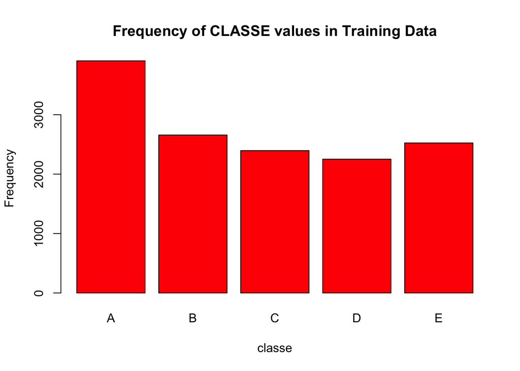

```r
set.seed(4321)
inTrain <- createDataPartition(y=training$classe, p=0.7, list = FALSE)
sub_training <- training[inTrain,]
sub_testing <- training[-inTrain,]

# Look at the 5 levels of Classe
plot(sub_training$classe, col="red", main="Frequency of CLASSE values in Training Data", xlab="classe", ylab="Frequency")
```

# Train and Predict

Because we don’t know which models will perform best at predicting the outcomes, several models will be used for analysis.

## Training Models

```r
timestamp()
```

```
## ##------ Sun Jan 29 17:47:25 2017 ------##
```

```r
model_rf    <- train(classe ~., data = sub_training, method="rf")
timestamp()
```

```
## ##------ Sun Jan 29 18:48:05 2017 ------##
```

```r
model_lda   <- train(classe ~., data = sub_training, method="lda")
timestamp()
```

```
## ##------ Sun Jan 29 18:48:15 2017 ------##
```

```r
model_gbm   <- train(classe ~., data = sub_training, method="gbm")
timestamp()
```

```
## ##------ Sun Jan 29 19:11:31 2017 ------##
```

```r
model_rpart <- train(classe ~., data = sub_training, method="rpart")
timestamp()
```

```
## ##------ Sun Jan 29 19:11:47 2017 ------##
```

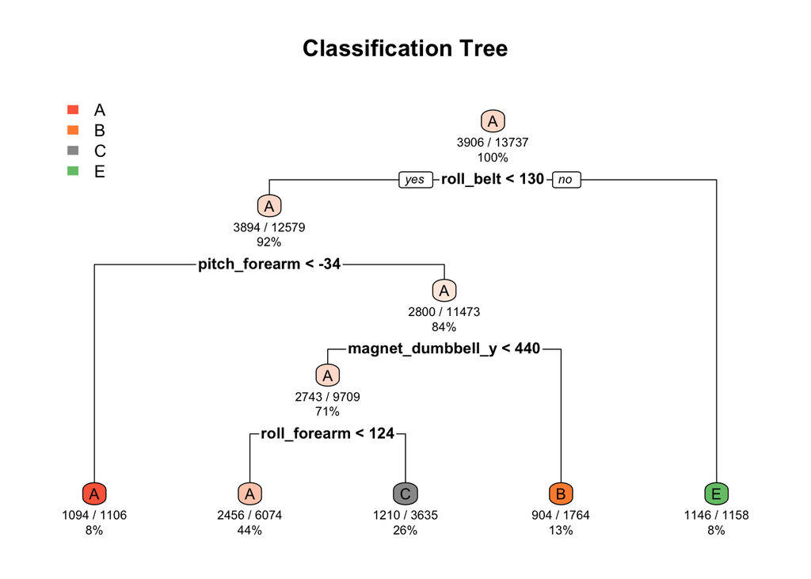

```r
rpart.plot(model_rpart$finalModel,main="Classification Tree", extra=102, under=TRUE)
```

## Predicting Models

Using the generated models, we supply the subset of testing data to establish predictions.

```r
predict_rf <- predict(model_rf, newdata=sub_testing)
predict_lda <- predict(model_lda, newdata=sub_testing)
predict_gbm <- predict(model_gbm, newdata=sub_testing)
predict_rpart <- predict(model_rpart, newdata=sub_testing)
```

Using the predictions generated for each of the models, we can analyze the accuracy between the varying models and identify if one model is sufficient, or if we should attempt to combine multiple models.

```r
# Random Forest (RF)
confusionMatrix(sub_testing$classe,predict_rf)
```

```
## Confusion Matrix and Statistics
##
##           Reference
## Prediction    A    B    C    D    E
##          A 1673    0    0    0    1
##          B    9 1126    4    0    0
##          C    0    4 1016    6    0
##          D    0    0    6  958    0
##          E    0    0    3    5 1074
##
## Overall Statistics
##
##                Accuracy : 0.9935
##                  95% CI : (0.9911, 0.9954)
##     No Information Rate : 0.2858
##     P-Value [Acc > NIR] : < 2.2e-16
##
##                   Kappa : 0.9918
##  Mcnemar's Test P-Value : NA
##
## Statistics by Class:
##
##                      Class: A Class: B Class: C Class: D Class: E
## Sensitivity            0.9946   0.9965   0.9874   0.9886   0.9991
## Specificity            0.9998   0.9973   0.9979   0.9988   0.9983
## Pos Pred Value         0.9994   0.9886   0.9903   0.9938   0.9926
## Neg Pred Value         0.9979   0.9992   0.9973   0.9978   0.9998
## Prevalence             0.2858   0.1920   0.1749   0.1647   0.1827
## Detection Rate         0.2843   0.1913   0.1726   0.1628   0.1825
## Detection Prevalence   0.2845   0.1935   0.1743   0.1638   0.1839
## Balanced Accuracy      0.9972   0.9969   0.9927   0.9937   0.9987
```

```r
# Linear Discriminate Analysis (LDA)
confusionMatrix(sub_testing$classe,predict_lda)
```

```
## Confusion Matrix and Statistics
##
##           Reference
## Prediction    A    B    C    D    E
##          A 1362   30  150  126    6
##          B  185  723  138   35   58
##          C  105  123  660  114   24
##          D   69   36  108  707   44
##          E   56  162  110  114  640
##
## Overall Statistics
##
##                Accuracy : 0.6953
##                  95% CI : (0.6834, 0.7071)
##     No Information Rate : 0.302
##     P-Value [Acc > NIR] : < 2.2e-16
##
##                   Kappa : 0.6142
##  Mcnemar's Test P-Value : < 2.2e-16
##
## Statistics by Class:
##
##                      Class: A Class: B Class: C Class: D Class: E
## Sensitivity            0.7665   0.6732   0.5660   0.6451   0.8290
## Specificity            0.9241   0.9135   0.9224   0.9463   0.9136
## Pos Pred Value         0.8136   0.6348   0.6433   0.7334   0.5915
## Neg Pred Value         0.9014   0.9260   0.8959   0.9210   0.9725
## Prevalence             0.3020   0.1825   0.1981   0.1862   0.1312
## Detection Rate         0.2314   0.1229   0.1121   0.1201   0.1088
## Detection Prevalence   0.2845   0.1935   0.1743   0.1638   0.1839
## Balanced Accuracy      0.8453   0.7934   0.7442   0.7957   0.8713
```

```r
# Generalized Boosted Model (GBM)
confusionMatrix(sub_testing$classe,predict_gbm)
```

```
## Confusion Matrix and Statistics
##
##           Reference
## Prediction    A    B    C    D    E
##          A 1653   16    2    3    0
##          B   35 1068   31    1    4
##          C    0   34  979   10    3
##          D    0    5   25  925    9
##          E    2   10   13   30 1027
##
## Overall Statistics
##
##                Accuracy : 0.9604
##                  95% CI : (0.9551, 0.9652)
##     No Information Rate : 0.2872
##     P-Value [Acc > NIR] : < 2.2e-16
##
##                   Kappa : 0.9499
##  Mcnemar's Test P-Value : 4.146e-06
##
## Statistics by Class:
##
##                      Class: A Class: B Class: C Class: D Class: E
## Sensitivity            0.9781   0.9426   0.9324   0.9546   0.9847
## Specificity            0.9950   0.9851   0.9903   0.9921   0.9886
## Pos Pred Value         0.9875   0.9377   0.9542   0.9595   0.9492
## Neg Pred Value         0.9912   0.9863   0.9854   0.9911   0.9967
## Prevalence             0.2872   0.1925   0.1784   0.1647   0.1772
## Detection Rate         0.2809   0.1815   0.1664   0.1572   0.1745
## Detection Prevalence   0.2845   0.1935   0.1743   0.1638   0.1839
## Balanced Accuracy      0.9866   0.9638   0.9613   0.9733   0.9867
```

```r
# Decision Tree (RPart)
confusionMatrix(sub_testing$classe,predict_rpart)
```

```
## Confusion Matrix and Statistics
##
##           Reference
## Prediction    A    B    C    D    E
##          A 1532   24  116    0    2
##          B  469  382  288    0    0
##          C  468   41  517    0    0
##          D  427  184  353    0    0
##          E  152  134  311    0  485
##
## Overall Statistics
##
##                Accuracy : 0.4955
##                  95% CI : (0.4826, 0.5084)
##     No Information Rate : 0.5179
##     P-Value [Acc > NIR] : 0.9997
##
##                   Kappa : 0.3408
##  Mcnemar's Test P-Value : NA
##
## Statistics by Class:
##
##                      Class: A Class: B Class: C Class: D Class: E
## Sensitivity            0.5026  0.49935  0.32618       NA  0.99589
## Specificity            0.9499  0.85215  0.88163   0.8362  0.88940
## Pos Pred Value         0.9152  0.33538  0.50390       NA  0.44824
## Neg Pred Value         0.6400  0.91930  0.78020       NA  0.99958
## Prevalence             0.5179  0.12999  0.26933   0.0000  0.08275
## Detection Rate         0.2603  0.06491  0.08785   0.0000  0.08241
## Detection Prevalence   0.2845  0.19354  0.17434   0.1638  0.18386
## Balanced Accuracy      0.7263  0.67575  0.60391       NA  0.94265
```

# Summary

Comparing the results from each of the model predictions, the **Random Forest model stands out clearly** as the most accurate model. With **99.4% accuracy** and an **out-of-sample error rate of 0.6%** (calculated as [1-Accuracy]), we expect very little missclassification in the final predictions of the provided test set using the **Random Forest Model**.

## Final Predictions

```r
predict_final <- predict(model_rf, newdata=testing)
predict_final
```

```
##  [1] B A B A A E D B A A B C B A E E A B B B
## Levels: A B C D E
```